# Extinction Threatens to Cause Morphological and Ecological Homogenization in Sharks

Supplementary Data:

Stanford Doer School of Sustainability, Paleobiology Lab

Author

Affiliation

[Mohamad Bazzi](https://github.com/mohabazzi)

[Stanford University](https://sustainability.stanford.edu/)

Published

2025-09-21

**Reproducibility statement**

This Quarto report accompanies the manuscript **Extinction Threatens to Cause Morphological and Ecological Homogenization in Sharks** submitted to **Science Advances**. It contains the full R code and analyses used to generate the results in the paper. All analyses were conducted in R version 4.5.1 with Quarto.

**Authors:** Mohamad Bazzi, Warwick L. Lloyd, Jun A. Ebersole, Phillip C. Sternes, Jood A. Al Aswad, and Jonathan L. Payne

## Data

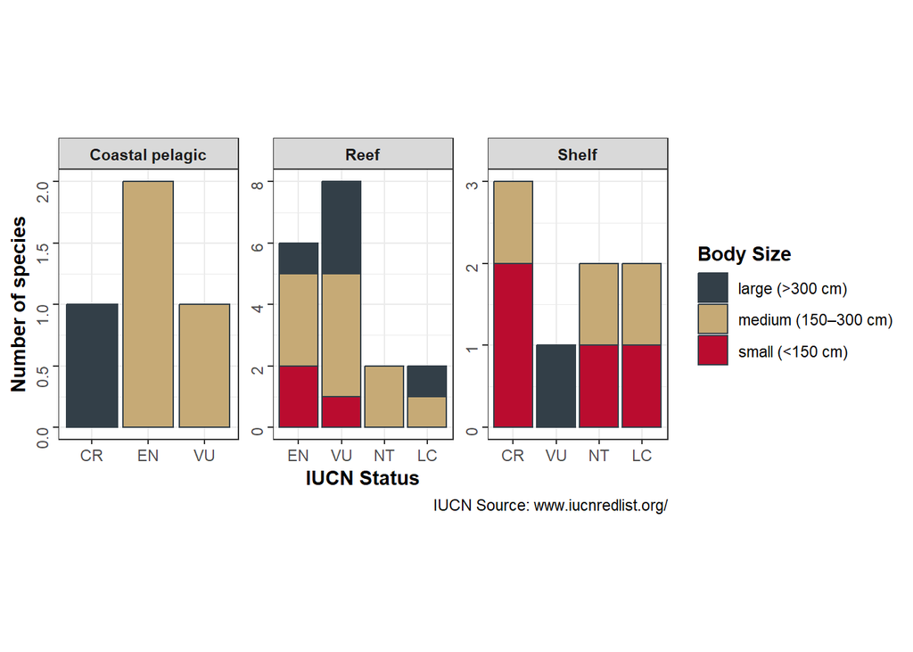

```r
# Morphometric dataset.
Data <-
  read.xlsx(xlsxFile = "Carcharhinus.xlsx") |>
  mutate(File.Type = ".png") |>
  # Remove C. wheeleri.
  filter(Species != "Carcharhinus wheeleri") |>
  filter(Used == "x") # 1256 specimens after removing C. wheeleri.

rownames(Data) <- paste(Data$File_Name,Data$File.Type,sep = "")

# Number of species.
carcharhinus_species <- unique(Data$Species)

# Habitat and IUCN information.
Traits <- read.xlsx(xlsxFile = "Traits.xlsx")

Traits |>
  mutate(Size_Subclass = gsub("_shark","",Size_Subclass)) |>
  mutate(Size_Subclass = case_when(Size_Subclass == "small" ~ "small (<150 cm)",
                                   Size_Subclass == "medium" ~ "medium (150–300 cm)",
                                   Size_Subclass == "large" ~ "large (>300 cm)", T  ~ Size_Subclass)) |>
  mutate("Body Size" = Size_Subclass) |>
  mutate(IUCN = factor(IUCN, levels = c("CR", "EN", "VU", "NT", "LC"))) |>
  group_by(`Body Size`, IUCN, Sorensen_habitat) |>
  count() |>
  ggplot(aes(x = IUCN, y = n, fill = `Body Size`)) +
  geom_bar(stat = "identity", colour = "#333F48FF") +
  scale_fill_manual(values =  c("#333F48FF","#C6AA76FF","#BA0C2FFF")) +
  labs(y = "Number of species", x = "IUCN Status", color = "Size Subclass",
       caption = "IUCN Source: www.iucnredlist.org/") +
  facet_wrap(~Sorensen_habitat, scales = "free") +
  theme_bw() +
  theme(axis.title = element_text(face = "bold"),
        plot.title = element_text(face = "bold"),
        axis.text.y = element_text(angle = 90,hjust = 1),
        legend.title = element_text(face = "bold"),
        strip.text = element_text(face = "bold"),
        aspect.ratio = 1.5)
```

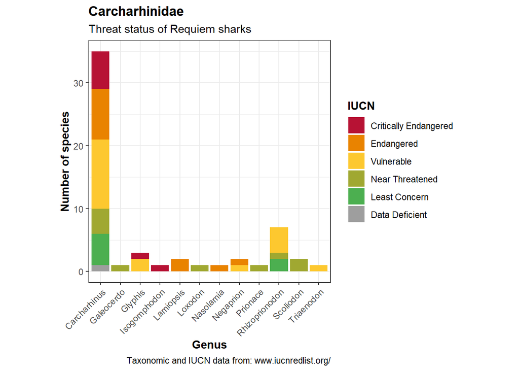

```r
# Coastal pelagic and large body size (>300 cm TL) would largely disappear if threatened taxa (CR, EN and VU) went extinct. C. galapagensis is globally LC and the only large-bodided, reef-associated species in this genus, that would not be affected.

# Proportions of species in each IUCN category?

# prop.table(table(Traits$IUCN)) |>
#   as.data.frame() |>
#   setNames(nm = c("IUCN","Proportion")) |>
#   ggplot(mapping = aes(x = IUCN, y = Proportion)) +
#   geom_col() +
#   coord_flip() +
#   theme(aspect.ratio = 1)

# Carcharhinidae species profiles.
carcharhinidae <- read.csv2(file = "Carcharhinidae.csv",header = T)
# Plot.
carcharhinidae |>
  mutate(IUCN = factor(IUCN, levels = c("Critically Endangered","Endangered","Vulnerable","Near Threatened","Least Concern","Data Deficient"))) |>
  group_by(Genus,IUCN) |>
  count() |>
  ggplot(mapping = aes(x = Genus, y = n, fill = IUCN)) +
  geom_bar(stat = "identity") +
  scale_fill_manual(values  = c("#B71234","#E98300","#FDC82F","#A0A831","#4CAF50","#9E9E9E")) +
  scale_color_manual(values = c("#B71234","#E98300","#FDC82F","#A0A831","#4CAF50","#9E9E9E")) +
  labs(x = "Genus", y = "Number of species", colour = "IUCN",
       title = "Carcharhinidae",subtitle = "Threat status of Requiem sharks",
       caption = "Taxonomic and IUCN data from: www.iucnredlist.org/") +
  theme_bw() +
  theme(axis.text.x = element_text(angle = 45,hjust = 1,vjust = 1),
        axis.title = element_text(face = "bold"),
        plot.title = element_text(face = "bold"),
        legend.title = element_text(face = "bold"),
        aspect.ratio = 1) # How many species of Carcharhinus?
```

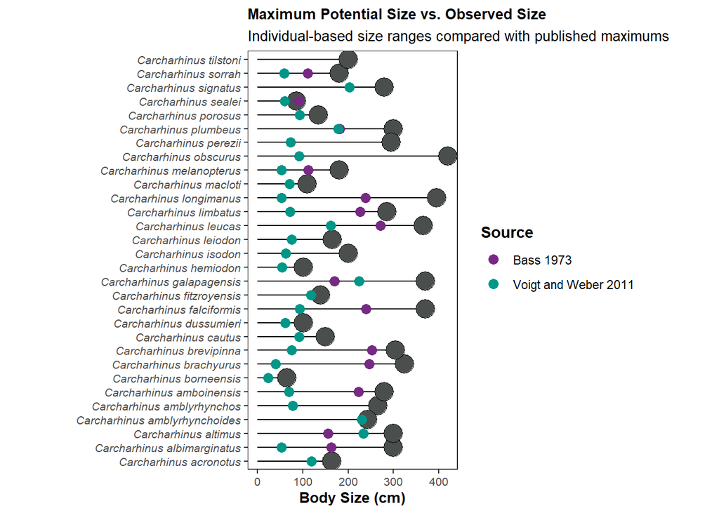

```r
# Compare sampled taxa against the maximum size of each species (max-values are from Ebert et al. 2024).
Traits |>
  select(Species,Max_Body_Size_Ebert_CM) |>
  mutate(Species = paste("Carcharhinus",Species)) |>
  rename("Size" = 2) |>
  ggplot(mapping = aes(x = Species, y = Size)) +
  geom_segment(aes(y = 0,yend = Size)) +
  geom_point(shape = 21, size = 6, fill = "#4a4e4d") +
  # Sampled specimens with tooth morphology.
  geom_point(data =
               Data |>
               group_by(Species,Source) |>
               # Carcharhinus tilstoni lacks TL information.
               filter(Species != "Carcharhinus tilstoni") |>
               summarise(max_size = max(TL,na.rm = T),min_size = min(TL,na.rm = T)) |>
               pivot_longer(cols = c(3:4),values_to = "Size") |>
               select(-3),mapping = aes(x = Species,y = Size, colour = Source),size = 3) +
  scale_fill_manual(values  = c("#762a83","#009688")) +
  scale_color_manual(values = c("#762a83","#009688")) +
  coord_flip() +
  labs(x = NULL,
       y = "Body Size (cm)",
       title = "Maximum Potential Size vs. Observed Size",
       subtitle = "Individual-based size ranges compared with published maximums") +
  theme_bw() +
  theme(panel.grid.major.y = element_blank(),
        panel.grid.minor.y = element_blank(),
        panel.grid.major.x = element_blank(),
        panel.grid.minor.x = element_blank(),
        axis.text.x = element_text(size = 8),
        axis.text.y = element_text(size = 8, face = "italic"),
        axis.title = element_text(face = "bold",size = 10),
        legend.position = "right",
        legend.title = element_text(face = "bold"),
        strip.text = element_text(face = "bold"),
        plot.title = element_text(face = "bold",size = 10),
        plot.subtitle = element_text(size = 10),
        aspect.ratio = 2)
```